# R Notebook

**Principles of Data Visualization and Introduction to ggplot2**

I have provided you with data about the 5,000 fastest growing companies in the US, as compiled by Inc. magazine. lets read this in:

```r
inc <- read.csv("https://raw.githubusercontent.com/charleyferrari/CUNY_DATA_608/master/module1/Data/inc5000_data.csv", header= TRUE)
```

And lets preview this data:

```r
head(inc)
```

[output not shown]

```r
summary(inc)
```

[output not shown]

Think a bit on what these summaries mean. Use the space below to add some more relevant non-visual exploratory information you think helps you understand this data:

```r
# Maximum and Minimum Growth Rate
(Growth_max <- inc[which.max(inc$Growth_Rate),])
(Growth_min <- inc[which.min(inc$Growth_Rate),])

# Maximum and Minimum Revenue
(Revenue_max <- inc[which.max(inc$Revenue),])
(Revenue_min <- inc[which.min(inc$Revenue),])

# Maximum and Minimum Employees
(Employees_max <- inc[which.max(inc$Employees),])
(Employees_min <- inc[which.min(inc$Employees),])
```

[output not shown]

## Loading libraries

```r
suppressMessages(if (!require('dplyr')) install.packages('dplyr'))
suppressMessages(if (!require('ggplot2')) install.packages('ggplot2'))
suppressMessages(if (!require('outliers')) install.packages('outliers'))
suppressMessages(if (!require('sqldf')) install.packages('sqldf'))
```

## Question 1

Create a graph that shows the distribution of companies in the dataset by State (ie how many are in each state). There are a lot of States, so consider which axis you should use. This visualization is ultimately going to be consumed on a ‘portrait’ oriented screen (ie taller than wide), which should further guide your layout choices.

```r
# Here we are using sqldf for writing the Sql code for data manipulation
q1 <- sqldf("select
          State, count(distinct Name) as number_companies
          from inc
          group by State")

ggplot(q1, aes(x=reorder(State,number_companies),number_companies))+
  geom_bar(stat="identity", fill="LightGreen")+
  geom_text(aes(label=round(number_companies, digits=2)), vjust=0.2, size=2.5, position=position_dodge(width = 1), hjust=1.5)+
  theme_minimal()+
  theme(axis.text.x=element_text(size=12, vjust=0.5))+
  theme(axis.text.y=element_text(size=8, vjust=0.5))+
  labs( x="State", y="Number of Unique Companies")+
  coord_flip()+
  labs(caption="Inc Data")+
  ggtitle("Distribution of Unique Companies by State")
```

[output not shown]

```r
ggsave('Q1.png')
```

## Quesiton 2

Lets dig in on the state with the 3rd most companies in the data set. Imagine you work for the state and are interested in how many people are employed by companies in different industries. Create a plot that shows the average and/or median employment by industry for companies in this state (only use cases with full data, use R’s `complete.cases()` function.) In addition to this, your graph should show how variable the ranges are, and you should deal with outliers.

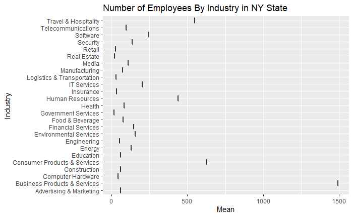

```r
q2 <- inc[complete.cases(inc), ]
q2 <- subset(inc, State == "NY")
q2 <- group_by(q2, Industry) %>% summarize(m = mean(Employees), max= max(Employees), min = min(Employees)) %>%
  na.omit()
upper <- q2$max
lower <- q2$min
ggplot(q2, aes(x = Industry, y =m, ymax=max,  ymin = min, lower = lower, upper= upper)) + geom_boxplot(outlier.shape = NA) + coord_flip()+
  labs(title="Number of Employees By Industry in NY State", y = "Mean")
ggsave('Q2.png')
```

```r
ggsave('Q2.png')
```

## Question 3

Now imagine you work for an investor and want to see which industries generate the most revenue per employee. Create a chart that makes this information clear. Once again, the distribution per industry should be shown.

```r
q3 <- inc[complete.cases(inc), ]
q3 <- q3[, c("Industry", "Revenue", "Employees")] %>% group_by(Industry) %>% summarise_each(funs(sum))
q3$RevPerEmp <- q3$Revenue / q3$Employees
ggplot(q3, aes(x = Industry, y = RevPerEmp)) +
  geom_point(aes(size = RevPerEmp), color = "Orange") +
  theme_bw() +
  theme(axis.text.x = element_text(angle = 45, vjust = 1, hjust=1))
```

[output not shown]

```r
ggsave('Q3.png')
```